[figure not shown]

# Project 2: Analyzing IMDb Data

*Author: Kevin Markham (DC)*

For project two, you will complete a serious of exercises exploring movie rating data from IMDb.

For these exercises, you will be conducting basic exploratory data analysis on IMDB's movie data, looking to answer such questions as:

What is the average rating per genre? How many different actors are in a movie?

This process will help you practice your data analysis skills while becoming comfortable with Pandas.

## Basic level

```python
import pandas as pd
import matplotlib.pyplot as plt
%matplotlib inline
```

#### Read in 'imdb_1000.csv' and store it in a DataFrame named movies.

```python
movies = pd.read_csv('./datasets/imdb_1000.csv')
movies.head()
```

|  | star_rating | title | content_rating | genre | duration | actors_list |
| --- | --- | --- | --- | --- | --- | --- |
| 0 | 9.3 | The Shawshank Redemption | R | Crime | 142 | [u'Tim Robbins', u'Morgan Freeman', u'Bob Gunt... |
| 1 | 9.2 | The Godfather | R | Crime | 175 | [u'Marlon Brando', u'Al Pacino', u'James Caan'] |
| 2 | 9.1 | The Godfather: Part II | R | Crime | 200 | [u'Al Pacino', u'Robert De Niro', u'Robert Duv... |
| 3 | 9.0 | The Dark Knight | PG-13 | Action | 152 | [u'Christian Bale', u'Heath Ledger', u'Aaron E... |
| 4 | 8.9 | Pulp Fiction | R | Crime | 154 | [u'John Travolta', u'Uma Thurman', u'Samuel L.... |

#### Check the number of rows and columns.

```python
# Answer:
movies.shape
```

```
(979, 6)
```

#### Check the data type of each column.

```python
# Answer:
movies.dtypes
```

```
star_rating       float64
title              object
content_rating     object
genre              object
duration            int64
actors_list        object
dtype: object
```

#### Calculate the average movie duration.

```python
# Answer:
movies.duration.mean()
```

```
120.97957099080695
```

#### Sort the DataFrame by duration to find the shortest and longest movies.

```python
# Answer:
shortest = movies.duration.min()
longest = movies.duration.max()
print(shortest)
print(longest)
```

```
64
242
```

#### Create a histogram of duration, choosing an "appropriate" number of bins.

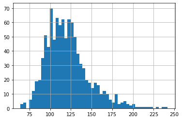

```python
# Answer:
movies.duration.hist(bins=50)
```

#### Use a box plot to display that same data.

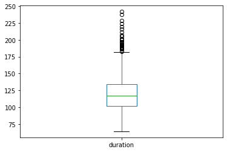

```python
# Answer:
movies.duration.plot(kind="box")
```

## Intermediate level

#### Count how many movies have each of the content ratings.

```python
# Answer:
movies.content_rating.value_counts()
```

```
R            460
PG-13        189
PG           123
NOT RATED     65
APPROVED      47
UNRATED       38
G             32
NC-17          7
PASSED         7
X              4
GP             3
TV-MA          1
Name: content_rating, dtype: int64
```

#### Use a visualization to display that same data, including a title and x and y labels.

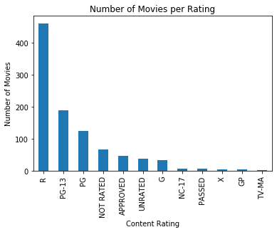

```python
# Answer:
movies.content_rating.value_counts().plot(kind='bar')
plt.xlabel('Content Rating');
plt.ylabel('Number of Movies');
plt.title('Number of Movies per Rating');
```

#### Convert the following content ratings to "UNRATED": NOT RATED, APPROVED, PASSED, GP.

```python
# Answer:

movies.content_rating.replace(['NOT RATED', 'APPROVED', 'PASSED', 'GP'],'UNRATED', inplace = True)
movies.head(20)
```

|  | star_rating | title | content_rating | genre | duration | actors_list |
| --- | --- | --- | --- | --- | --- | --- |
| 0 | 9.3 | The Shawshank Redemption | R | Crime | 142 | [u'Tim Robbins', u'Morgan Freeman', u'Bob Gunt... |
| 1 | 9.2 | The Godfather | R | Crime | 175 | [u'Marlon Brando', u'Al Pacino', u'James Caan'] |
| 2 | 9.1 | The Godfather: Part II | R | Crime | 200 | [u'Al Pacino', u'Robert De Niro', u'Robert Duv... |
| 3 | 9.0 | The Dark Knight | PG-13 | Action | 152 | [u'Christian Bale', u'Heath Ledger', u'Aaron E... |
| 4 | 8.9 | Pulp Fiction | R | Crime | 154 | [u'John Travolta', u'Uma Thurman', u'Samuel L.... |
| 5 | 8.9 | 12 Angry Men | UNRATED | Drama | 96 | [u'Henry Fonda', u'Lee J. Cobb', u'Martin Bals... |
| 6 | 8.9 | The Good, the Bad and the Ugly | UNRATED | Western | 161 | [u'Clint Eastwood', u'Eli Wallach', u'Lee Van ... |
| 7 | 8.9 | The Lord of the Rings: The Return of the King | PG-13 | Adventure | 201 | [u'Elijah Wood', u'Viggo Mortensen', u'Ian McK... |
| 8 | 8.9 | Schindler's List | R | Biography | 195 | [u'Liam Neeson', u'Ralph Fiennes', u'Ben Kings... |
| 9 | 8.9 | Fight Club | R | Drama | 139 | [u'Brad Pitt', u'Edward Norton', u'Helena Bonh... |
| 10 | 8.8 | The Lord of the Rings: The Fellowship of the Ring | PG-13 | Adventure | 178 | [u'Elijah Wood', u'Ian McKellen', u'Orlando Bl... |
| 11 | 8.8 | Inception | PG-13 | Action | 148 | [u'Leonardo DiCaprio', u'Joseph Gordon-Levitt'... |
| 12 | 8.8 | Star Wars: Episode V - The Empire Strikes Back | PG | Action | 124 | [u'Mark Hamill', u'Harrison Ford', u'Carrie Fi... |
| 13 | 8.8 | Forrest Gump | PG-13 | Drama | 142 | [u'Tom Hanks', u'Robin Wright', u'Gary Sinise'] |
| 14 | 8.8 | The Lord of the Rings: The Two Towers | PG-13 | Adventure | 179 | [u'Elijah Wood', u'Ian McKellen', u'Viggo Mort... |
| 15 | 8.7 | Interstellar | PG-13 | Adventure | 169 | [u'Matthew McConaughey', u'Anne Hathaway', u'J... |
| 16 | 8.7 | One Flew Over the Cuckoo's Nest | R | Drama | 133 | [u'Jack Nicholson', u'Louise Fletcher', u'Mich... |
| 17 | 8.7 | Seven Samurai | UNRATED | Drama | 207 | [u'Toshir\xf4 Mifune', u'Takashi Shimura', u'K... |
| 18 | 8.7 | Goodfellas | R | Biography | 146 | [u'Robert De Niro', u'Ray Liotta', u'Joe Pesci'] |
| 19 | 8.7 | Star Wars | PG | Action | 121 | [u'Mark Hamill', u'Harrison Ford', u'Carrie Fi... |

#### Convert the following content ratings to "NC-17": X, TV-MA.

```python
# Answer:
movies.content_rating.replace(['X','TV-MA'], 'NC-17', inplace=True)
```

#### Count the number of missing values in each column.

```python
# Answer:
movies.isnull().sum()
```

```
star_rating       0
title             0
content_rating    3
genre             0
duration          0
actors_list       0
dtype: int64
```

#### If there are missing values: examine them, then fill them in with "reasonable" values.

```python
# Answer:
movies[movies.content_rating.isnull()]
movies["content_rating"].fillna("URATED2", inplace = True)
movies.isnull().sum()
```

```
star_rating       0
title             0
content_rating    0
genre             0
duration          0
actors_list       0
dtype: int64
```

#### Calculate the average star rating for movies 2 hours or longer, and compare that with the average star rating for movies shorter than 2 hours.

```python
# Answer:
movies.star_rating.mean()

AvgStarShort = movies[movies.duration < 120].star_rating.mean()
print(AvgStarShort)

AvgStarLong = movies[movies.duration >= 120].star_rating.mean()
print(AvgStarLong)
```

```
7.838666666666657
7.948898678414082
```

#### Use a visualization to detect whether there is a relationship between duration and star rating.

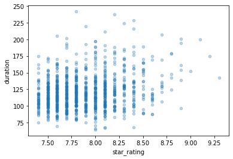

```python
# Answer:
movies.plot(kind = 'scatter', x = "star_rating", y = 'duration', alpha =  0.3)
```

#### Calculate the average duration for each genre.

```python
# Answer:
movies.groupby('genre').duration.mean()
```

```
genre
Action       126.485294
Adventure    134.840000
Animation     96.596774
Biography    131.844156
Comedy       107.602564
Crime        122.298387
Drama        126.539568
Family       107.500000
Fantasy      112.000000
Film-Noir     97.333333
History       66.000000
Horror       102.517241
Mystery      115.625000
Sci-Fi       109.000000
Thriller     114.200000
Western      136.666667
Name: duration, dtype: float64
```

## Advanced level

#### Visualize the relationship between content rating and duration.

```
array([[<matplotlib.axes._subplots.AxesSubplot object at 0x126643a58>,
      dtype=object)
```

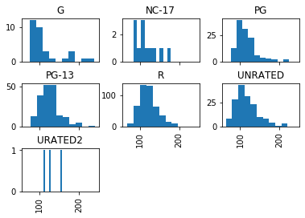

```python
# Answer:
movies.duration.hist(by = movies.content_rating, sharex = True)
```

#### Determine the top rated movie (by star rating) for each genre.

```python
# Answer:
movies.sort_values('star_rating', ascending = False).title.head(1)
```

```
0    The Shawshank Redemption
Name: title, dtype: object
```

#### Check if there are multiple movies with the same title, and if so, determine if they are actually duplicates.

```python
# Answer:
same_title = movies[movies.title.duplicated()].title
movies[movies.title.isin(same_title)]
```

|  | star_rating | title | content_rating | genre | duration | actors_list |
| --- | --- | --- | --- | --- | --- | --- |
| 466 | 7.9 | The Girl with the Dragon Tattoo | R | Crime | 158 | [u'Daniel Craig', u'Rooney Mara', u'Christophe... |
| 482 | 7.8 | The Girl with the Dragon Tattoo | R | Crime | 152 | [u'Michael Nyqvist', u'Noomi Rapace', u'Ewa Fr... |
| 662 | 7.7 | True Grit | PG-13 | Adventure | 110 | [u'Jeff Bridges', u'Matt Damon', u'Hailee Stei... |
| 678 | 7.7 | Les Miserables | PG-13 | Drama | 158 | [u'Hugh Jackman', u'Russell Crowe', u'Anne Hat... |
| 703 | 7.6 | Dracula | UNRATED | Horror | 85 | [u'Bela Lugosi', u'Helen Chandler', u'David Ma... |
| 905 | 7.5 | Dracula | R | Horror | 128 | [u'Gary Oldman', u'Winona Ryder', u'Anthony Ho... |
| 924 | 7.5 | Les Miserables | PG-13 | Crime | 134 | [u'Liam Neeson', u'Geoffrey Rush', u'Uma Thurm... |
| 936 | 7.4 | True Grit | URATED2 | Adventure | 128 | [u'John Wayne', u'Kim Darby', u'Glen Campbell'] |

#### Calculate the average star rating for each genre, but only include genres with at least 10 movies

#### Option 1: manually create a list of relevant genres, then filter using that list

```python
# Answer:
movies.genre.value_counts()
big_genre = ['Drama', 'Comedy', 'Action', 'Crime', 'Biography', 'Adventure', 'Animation', 'Horror', 'Mystery']
movies[movies.genre.isin(big_genre)].groupby('genre').star_rating.mean()
```

```
genre
Action       7.884559
Adventure    7.933333
Animation    7.914516
Biography    7.862338
Comedy       7.822436
Crime        7.916935
Drama        7.902518
Horror       7.806897
Mystery      7.975000
Name: star_rating, dtype: float64
```

#### Option 2: automatically create a list of relevant genres by saving the value_counts and then filtering

```python
# Answer:
```

#### Option 3: calculate the average star rating for all genres, then filter using a boolean Series

```python
# Answer:
```

#### Option 4: aggregate by count and mean, then filter using the count

```python
# Answer:
```

## Bonus

#### Figure out something "interesting" using the actors data!